# Adquisición y Procesamiento de Señales Biomédicas en Tecnologías de Borde

Ingeniería Biomédica

Ph.D. Pablo Eduardo Caicedo Rodríguez

2025-01-20

# Adquisición y Procesamiento de Señales Biomédicas en Tecnologías de Borde - APSB

# Machine Learning Introduction

## What is Machine Learning?

- Machine Learning (ML) is a data-driven approach to building predictive models.
- It is used in various applications such as healthcare, finance, and automation.
- It is based on identifying patterns in data to make predictions or decisions.

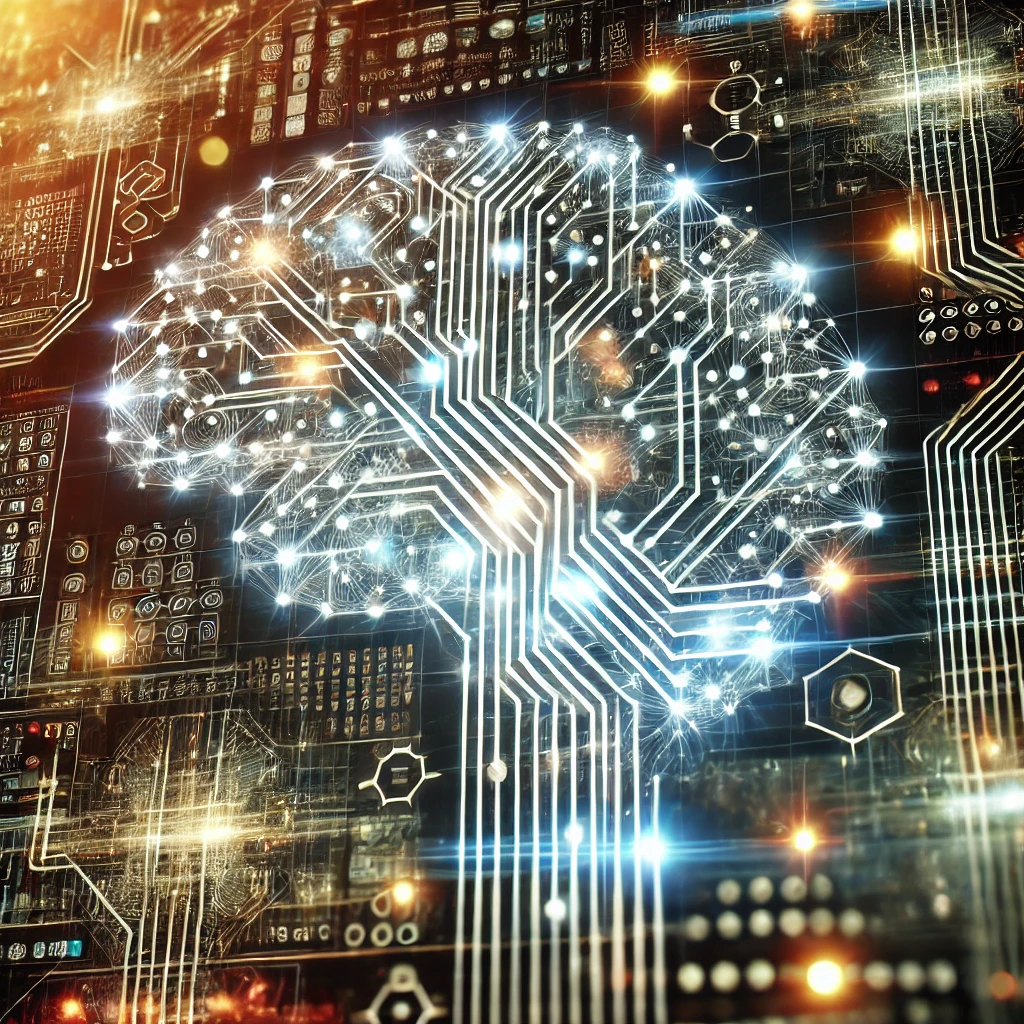

## What is Machine Learning?

- ML enables systems to learn from experience without being explicitly programmed.
- Key application areas include image recognition, natural language processing, and autonomous systems.

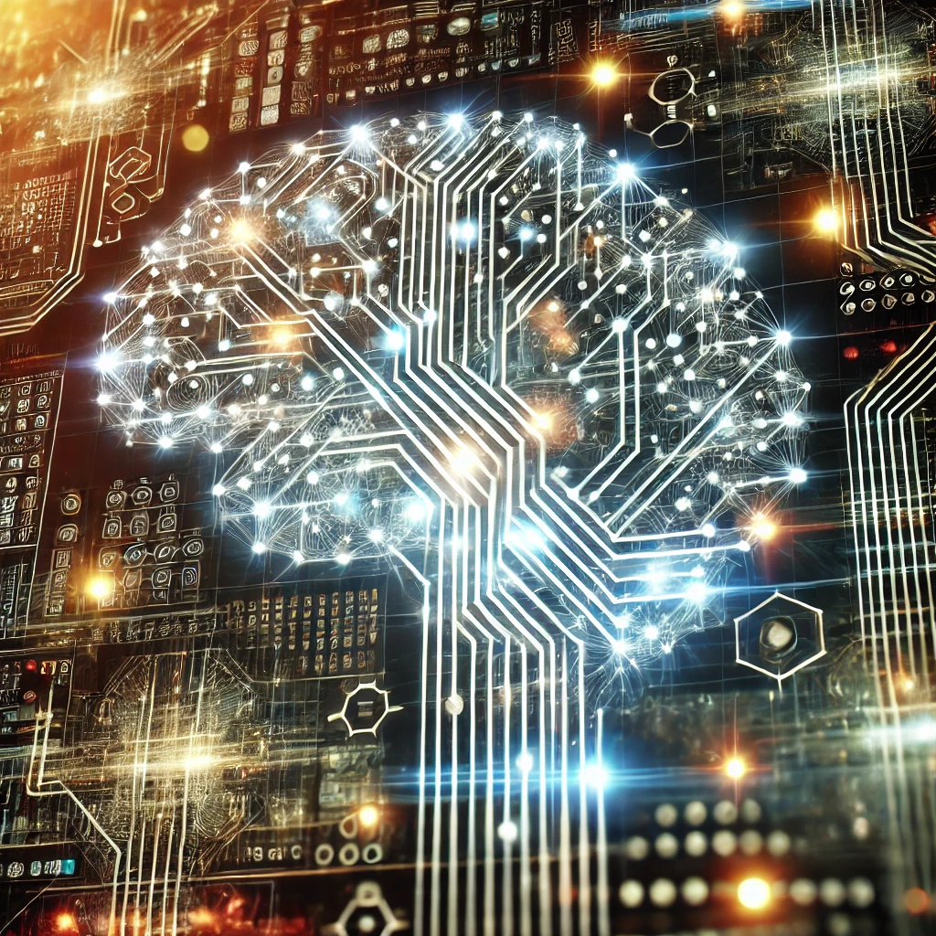

## Types of Machine Learning – Supervised Learning

**Supervised Learning**: - Uses labeled data to train models. - Example: Spam detection in emails (spam vs. non-spam). - Common algorithms: Linear Regression, Decision Trees, Support Vector Machines (SVM), Neural Networks.

## Types of Machine Learning – Unsupervised Learnin

**Unsupervised Learning**: - Finds patterns in unlabeled data. - Example: Customer segmentation in marketing. - Common algorithms: K-Means Clustering, Hierarchical Clustering, Principal Component Analysis (PCA).

## Types of Machine Learning – Reinforcement Learning

**Reinforcement Learning**: - Optimizes decision-making through rewards. - Example: Training an AI to play a game like Chess or Go. - Key components: Agent, Environment, Reward Signal.

## Key Components of an ML Model

- **Data**:
  - The quality and quantity of data are fundamental.
  - Data preprocessing (cleaning, normalization, feature extraction) is crucial.
- **Model**:
  - A mathematical representation of the problem.
  - Chosen based on the problem type (classification, regression, clustering).

## Key Components of an ML Model

- **Error function**:
  - Evaluates the difference between prediction and actual value.
  - Example: Mean Squared Error (MSE) for regression, Cross-Entropy Loss for classification.
- **Optimization**:
  - Algorithms that adjust the model parameters to minimize error.
  - Common optimization techniques: Gradient Descent, Adam Optimizer.

## Bias and Inductivity

- **Inductive Bias**:
  - Prior assumptions that the model uses to generalize.
  - Example: Linear models assume data relationships are linear.
- **Sample Bias**:
  - Differences between training data and real-world data.
  - Example: A face recognition system trained on a specific demographic may perform poorly on others.

## Bias and Inductivity

- **Bias-Variance Tradeoff**:
  - **High Bias (Underfitting)**: The model is too simple, failing to capture patterns.
  - **High Variance (Overfitting)**: The model memorizes training data but fails on new data.

## Example of Bias and Variance

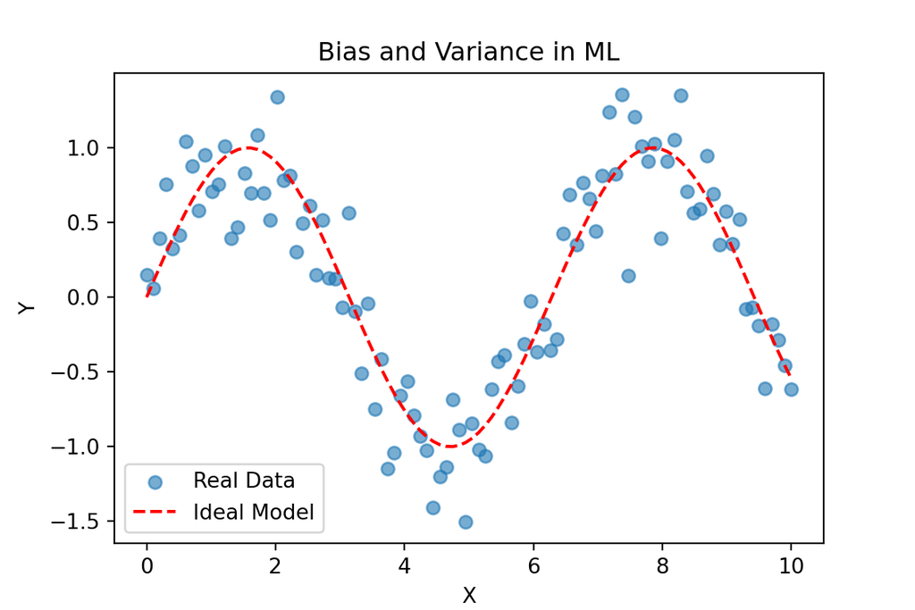

## Basic Machine Learning Algorithms

### 1. **Linear Regression** (Supervised Learning - Regression)

- Predicts a continuous value based on input features.
- Equation: ( y = mx + b )
- Example: Predicting house prices based on square footage.

```
LinearRegression()
```

```
Slope: [0.6]
```

```
Intercept: 2.2
```

## Basic Machine Learning Algorithms

### 2. **Decision Trees** (Supervised Learning - Classification & Regression)

- Splits data into decision nodes to make predictions.
- Example: Diagnosing a disease based on symptoms.

```
DecisionTreeClassifier()
```

```
Prediction for [1,1]: [1]
```

## Basic Machine Learning Algorithms

### 3. **K-Means Clustering** (Unsupervised Learning)

- Groups similar data points together.
- Example: Customer segmentation in marketing.

```
Cluster Centers: [[10.  2.]
 [ 1.  2.]]
```

## Basic Machine Learning Algorithms

### 4. **Support Vector Machines (SVM)** (Supervised Learning - Classification)

- Finds a hyperplane that best separates different classes.
- Example: Classifying tumors as benign or malignant.

```
SVC()
```

```
Prediction for [1,1]: [1]
```

## Basic Machine Learning Algorithms

### 5. **Reinforcement Learning Example**

- Uses rewards and penalties to train an agent to make optimal decisions.
- Example: A robot learning to navigate a maze.

```
Trained Q-Table:
 [[0.25615649 0.30878782 0.41058013 0.51491964 0.61034011]
 [0.3107379  0.38073591 0.48471908 0.61301741 1.01935099]
 [0.37239851 0.50759847 0.97612008 0.98317064 1.95285156]
 [0.51627167 0.84670633 1.85764033 2.76759831 4.05486034]
 [0.71785175 0.9443301  2.80275594 6.18910807 0.        ]]
```